RESEARCH ARTICLE

Why Most Acute Stroke Studies Are

Positive in Animals but Not in Patients:

A Systematic Comparison of Preclinical,

Early Phase, and Phase 3 Clinical Trials

of Neuroprotective Agents

Antje Schmidt-Pogoda, MD

,<sup>1,</sup>†Nadine Bonberg, MSc,<sup>2,</sup>†Mailin Hannah Marie Koecke,<sup>1</sup>

Jan-Kolja Strecker, PhD,<sup>1</sup>Jürgen Wellmann, PhD,<sup>2</sup>Nils-Martin Bruckmann, MD,<sup>1</sup>

Carolin Beuker, MD,<sup>1</sup>Wolf-Rüdiger Schäbitz, MD,<sup>3</sup>Sven G. Meuth, MD, PhD,<sup>1</sup>

Heinz Wiendl, MD,<sup>1</sup>Heike Minnerup, MD, MSc,<sup>2</sup>and Jens Minnerup, MD<sup>1</sup>

Objective: To analyze why numerous acute stroke treatments were successful in the laboratory but failed in large clini-

cal trials.

Methods: We searched all phase 3 trials of medical treatments for acute ischemic stroke and corresponding early clini-

cal and experimental studies. We compared the overall efﬁcacy and assessed the impact of publication bias and study

design on the efﬁcacy. Furthermore, we estimated power and true report probability of experimental studies.

Results: We identiﬁed 50 phase 3 trials with 46,008 subjects, 75 early clinical trials with 12,391 subjects, and 209 experi-

mental studies with >7,141 subjects. Three (6%) phase 3, 24 (32%) early clinical, and 143 (69.08%) experimental studies

were positive. The mean treatment effect was 0.76 (95% conﬁdence interval [CI] = 0.70–0.83) in experimental studies, 0.87

(95% CI = 0.71–1.06) in early clinical trials, and 1.00 (95% CI = 0.95–1.06) in phase 3 trials. Funnel plot asymmetry and trim-

and-ﬁll revealed a clear publication bias in experimental studies and early clinical trials. Study design and adherence to

quality criteria had a considerable impact on estimated effect sizes. The mean power of experimental studies was 17%.

Assuming a bias of 30% and pre-study odds of 0.5 to 0.7, this leads to a true report probability of <50%.

Interpretation: Pivotal study design differences between experimental studies and clinical trials, including different pri-

mary end points and time to treatment, publication bias, neglected quality criteria and low power, contribute to the

stepwise efﬁcacy decline of stroke treatments from experimental studies to phase 3 clinical trials. Even under conserva-

tive estimates, less than half of published positive experimental stroke studies are truly positive.

ANN NEUROL 2020;87:40–51

S

troke is a leading cause of death and disability.<sup>1</sup>None-

theless, intravenous thrombolysis with tissue plasmino-

gen activator (tPA) and thrombectomy are still the only

approved treatments for acute ischemic stroke,<sup>2</sup>and stroke

researchers are desperate to identify novel treatment strate-

gies beyond recanalization, i.e. neuroprotective treatments.

In the last few decades, more than 1,000 acute stroke treat-

ments have been tested in the laboratory.<sup>3</sup>Strikingly, the

View this article online at wileyonlinelibrary.com. DOI: 10.1002/ana.25643

Received Mar 20, 2019, and in revised form Nov 11, 2019. Accepted for publication Nov 11, 2019.

Address correspondence to Dr Schmidt-Pogoda, Albert-Schweitzer-Campus 1, Gebäude A1, 48149 Münster, Germany.

E-mail: antje.schmidt-pogoda@ukmuenster.de

†A.S.-P. and N.B. contributed equally.

From the <sup>1</sup>Department of Neurology, Institute of Translational Neurology, University of Münster, Münster; <sup>2</sup>Institute of Epidemiology and Social Medicine,

University of Münster, Münster; and <sup>3</sup>Department of Neurology, Evangelical Hospital Bethel, Bielefeld, Germany

Additional supporting information can be found in the online version of this article.

© 2019 The Authors. Annals of Neurology published by Wiley Periodicals, Inc. on behalf of American Neurological Association.

40

This is an open access article under the terms of the Creative Commons Attribution-NonCommercial License, which permits use, distribution

and reproduction in any medium, provided the original work is properly cited and is not used for commercial purposes.

majority of acute stroke treatments achieved great success in

animal studies but eventually failed in large clinical trials.<sup>3</sup>

As a consequence, the perception that “everything works in

animals but nothing works in people” dominates stroke

research, and numerous commentaries and review articles

on the so called “translational roadblock” between animal

studies and clinical trials have been published.<sup>3</sup><sup>–</sup><sup>5</sup>Strictly

speaking, we do not observe a single roadblock between ani-

mal experiments and human stroke patients but rather a

stepwise efﬁcacy decline from highly successful animal stud-

ies to partly successful early clinical trials to neutral phase

3 clinical trials. Here, we systematically analyzed differences

in the study design of experimental studies, early phase clini-

cal trials, and phase 3 clinical trials, and we evaluated in how

far these differences led to overestimated efﬁcacy of acute

stroke treatments in experimental stroke studies and early

clinical trials.

Methods

Identiﬁcation of Studies and Data Extraction

We systematically searched the databases Clinicaltrials.gov

(searched in August 2017) and the Internet Stroke Center

(searched in August 2017) to identify all phase 3 clinical tri-

als of medical treatments for acute ischemic stroke,

i.e. candidate neuroprotectants. Our search of the database

Clinicaltrials.gov included the terms “closed studies” for

“recruitment,” “all studies” for “study result,” “interven-

tional studies” for “study type,” and “phase III” for “phase.”

Our search of the Internet Stroke Center involved the terms

“completed” and “terminated” for “status,” and “phase III”

for “phase.” Because we aimed to focus on acute treatments,

trials were only included if the intervention started within

the ﬁrst 72 hours from symptom onset. To determine

corresponding experimental studies and early phase clinical

trials of identiﬁed phase 3 trials, we searched Pubmed from

the beginning until August 2017 using the terms “stroke” or

“ischemia” or “infarct” and “drug name” or “abbreviated

drug name.” We included only studies reporting functional

outcomes and/or infarct volumes. Studies using hemorrhagic

stroke models, electrolytic brain lesions and pretreatment,

and treatment arms involving comedication other than

recombinant tPA (rtPA) were excluded. An overview of

inclusion and exclusion criteria is provided in the supple-

mentary material (Supplementary Table). We extracted data

on the number of subjects in each treatment arm, functional

outcomes, infarct volumes, study quality, time to treatment,

and statistical methods. When data were presented graphi-

cally only, values were read off the graphics using ImageJ

(public domain software). Study identiﬁcation and data

extraction were performed by 2 independent investigators

(A.S.-P. and M.K. identiﬁed all studies, A.S.-P. and

M.K. extracted data from experimental studies, A.S.-P. and

N.-M.B. extracted data from early clinical trials and phase

3 clinical trials). Disagreements were resolved in discussion

with a third investigator (C.B.).

Statistical Methods

We performed meta-analyses to illustrate the gradual efﬁcacy

decline of acute stroke treatments from experimental studies

to early clinical trials to phase 3 clinical trials. For continu-

ous outcomes like infarct volumes, we extracted mean values

and their standard errors (SEs) for each treatment group and

control group. If not provided directly, the SE was com-

puted by dividing the standard deviation by the square root

of the number of animals per group. If only median and

quantiles were reported, we used the median as location

parameter and estimated the SE of the mean with a scaled

interquartile range due to normality assumption. For infarct

volumes and functional outcomes in experimental studies,

we quantiﬁed treatment effects by the ratios of the outcomes

of treatment groups and corresponding control groups, and

we approximated the corresponding SEs by the delta

method.<sup>6</sup>We used the ratio of means instead of the differ-

ence of means for the following reasons: First, animal experi-

ments were performed in rats, mice, and rabbits, which all

have different brain sizes. Second, we included studies with

different infarct models, for example, middle cerebral artery

occlusion and photothrombosis, which produce different

infarct sizes. Third, infarct sizes were provided in different

units (mm<sup>3</sup>and percent). Using the ratio of means, units

and multiplication factors can be cancelled so that these

studies can be compared, independent of the animal strain,

infarct model, and the reported unit for infarct size. Another

advantage is that response ratios are multiplicative values

indicating the proportion of brain that can be saved by a cer-

tain treatment. For studies reporting binary outcomes—for

example, the proportion of patients achieving a modiﬁed

Rankin scale of 0 to 1 after 3 months—we quantiﬁed treat-

ment effects by odds ratios and their conﬁdence intervals

(CIs). If more than one verum group was available, verum

groups were combined. To this end, means of continuous

outcomes were weighted with inverse variance, and means

of proportions were weighted with group size.

Our meta-analyses included all experimental studies

in which mean infarct volumes or means of functional

outcomes and corresponding SEs were either denoted

directly or could be determined as described previously

and all early clinical trials and phase 3 clinical trials that

provided binary functional outcomes. Calculations were

performed with R version 3.5.2. Meta-analyses were per-

formed with the metafor package using random-effects

models, as previously described.<sup>7</sup>To analyze how much

time to treatment and adherence to quality criteria such as

January 2020

41

Schmidt-Pogoda et al: Why Neuroprotection Works in Animals

TABLE Overview of Included Studies

Treatment

Phase 3 Trials, n

Subjects in

Phase 3 Trials, n

Early

Clinical Trials, n

Subjects in

Early Clinical Trials, n

Experimental

Studies, n

Subjects in

Experimental

Studies, n

Acetaminophen

1

1,400

5

458

0

0

Albumin

1

841

2

346

17

462

Aptiganel

1

628

2

659

7

165

Atenolol

1

201

0

0

0

0

BMS-204352

1

1,977

0

0

1

108

Candesartan

1

2,029

1

342

18

500

Cervene

1

368

2

366

0

0

Chlomethiazole

2

2,558

2

1,550

4

60

Citicoline

3

3,591

6

934

18

512

Diazepam

1

880

0

0

1

37

DP-b99

1

446

1

150

0

0

Ebselen

1

302

1

105

5

225

Edaravone

1

814

9

1,429

20

253

Eliprodil

1

483

0

0

3

179

Enlimomab

1

635

0

7

262

Epoetin alfa

1

522

3

262

33

>1,372

FGF

1

286

0

0

16

655

Flunarizine

1

331

2

357

1

74

Fosphenytoin

1

462

0

0

0

0

Gavestinel

2

3,171

4

474

2

84

Ginsenoside-Rd

1

386

1

199

0

0

GM1 ganglioside

3

1,581

4

727

4

93

Isradipine

1

357

0

0

3

61

Lubeluzole

2

2,507

4

1,029

3

87

Magnesium

2

4,086

5

296

3

112

Naftidrofuryl

1

620

1

100

2

>16

NeuroAiD

1

1,099

1

150

0

0

Nimodipine

4

3,028

12

1,769

10

200

NXY-059

2

5,028

1

134

10

540

ONO-2506

1

841

1

92

1

108

Piracetam

1

927

0

0

2

50

Repinotan

1

681

1

240

1

316

Selfotel

1

567

1

32

2

37

Tirilazad

2

682

1

111

8

137

Uric acid

1

411

2

48

0

0

UK-279,276

1

966

0

0

0

0

YM872

1

312

0

0

7

436

Total

50

46,008

75

12,391

209

>7,141

FGF = ﬁbroblast growth factor.

42

Volume 87, No. 1

ANNALS of Neurology

randomization, blinded outcome assessment, and the

inclusion of subjects with comorbidities inﬂuence the

treatment effect, we added these variables as inﬂuential

variables in random-effects models.<sup>7</sup>

The publication bias in experimental studies, early

clinical trials, and phase 3 clinical trials was estimated by

funnel plot asymmetry and a trim-and-ﬁll approach, as pre-

viously described.<sup>8</sup>To prepare funnel plots, we plotted the

effect estimates from individual studies against each study’s

precision, that is, the reciprocal value of the SE. We chose a

reversed vertical scale that places larger, more powerful stud-

ies toward the top. In consequence, effect estimates from

smaller studies should scatter more widely at the bottom,

whereas the scatter of larger studies narrows toward the

top.<sup>9</sup>The concept of funnel plotting is based on the

assumption that imprecise studies are as likely to overstate

efﬁcacy as to understate efﬁcacy, thus resulting in a plot that

resembles an inverted funnel. If publication bias is present,

there is an imbalance in favor of imprecise studies which

overstate efﬁcacy, whereas the counterpart of imprecise stud-

ies that understate efﬁcacy is missing.<sup>8</sup>The trim-and-ﬁll

method is a nonparametric data augmentation technique

proposed by Duval and Tweedie.<sup>10</sup>In the trim-and-ﬁll

approach, studies with the most extreme effect sizes are

suppressed, and the overall estimate of efﬁcacy is rec-

alculated. This process is repeated until there are no more

studies to exclude. Thereafter, suppressed studies are rep-

laced together with imputed counterparts, which are deter-

mined by reﬂection around the recalculated overall estimate

of efﬁcacy.<sup>10</sup>Meta-analysis of this data set gives an estimate

of the actual efﬁcacy, and the number of imputed counter-

parts gives an idea of the number of unpublished studies.<sup>10</sup>

Power analyses for experimental studies were per-

formed with the pwr package.<sup>11</sup>Power analyses were

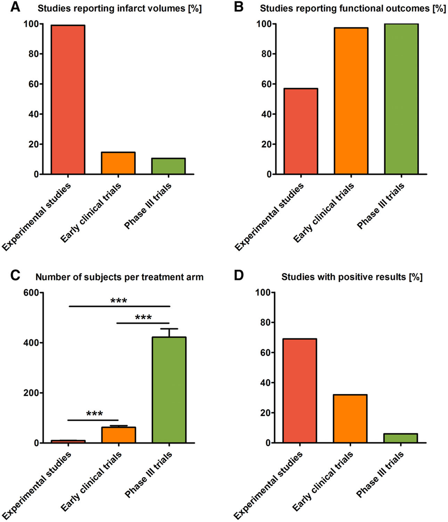

FIGURE 1: General study characteristics. (A) Almost all experimental studies (99.03%) presented infarct volumes as main end

point, whereas only 14.66% of early clinical and 10.64% of phase 3 clinical trials reported infarct volumes. (B) All phase 3 trials

and almost all early clinical trials (97.33%) presented functional outcomes as main end point, whereas only 57% of experimental

studies provided functional outcomes. (C) There were highly signiﬁcant differences (triple asterisks) in the mean number of

subjects per treatment arm (p < 0.001, one-way analysis of variance). (D) There were 69.08% of experimental studies, 32% of

early clinical, and 6% of phase 3 clinical trials that reported at least 1 signiﬁcant positive major end point, that is, either

improved functional outcome or infarct volume reduction.

January 2020

43

Schmidt-Pogoda et al: Why Neuroprotection Works in Animals

based on a 2-sample (2-sided) t test, and we assumed that

the logarithms of infarct volumes in placebo groups ln(VP)

and verum groups ln(VV) were distributed normally. As

expectable effect, we chose the estimator of the meta-anal-

ysis ln(response ratio [RR]) = ln(0.76) = ln(VV) – ln(Vp)

from experimental studies and assumed homogeneity of

variance. As an estimator for variance, we calculated a with

the sample size weighted mean of variances in experimen-

tal studies and determined Cohen’s d = −0.47.

The true report probability (trp) of experimental

studies was estimated by the previously deﬁned formula

trp = ([1 − β]R + uβR)/(R + α − βR + u − uα + uβR).<sup>12</sup>

In this formula, R is the prestudy odds of true H0 to H1

hypotheses, U is the proportion of probed analyses that

would not have been “research ﬁndings” but ended up

being reported as such because of bias, (1 − β) is the

study power, and α is the type 1 error rate.<sup>10</sup>

Results

Included Studies and General Study

Characteristics

Our search identiﬁed 50 phase 3 clinical trials on 37 treat-

ments with 46,008 patients; 209 corresponding animal

experimental studies with more than 7,141 subjects; and

75 corresponding early clinical trials with 12,391 patients

(Table). Vote-count meta-analyses revealed intriguing dif-

ferences in general study characteristics between experimen-

tal studies, early clinical trials, and phase 3 clinical trials:

99.03% of experimental studies provided infarct volumes as

main end points, whereas most clinical studies reported

only neurological outcomes (Fig 1). Mean numbers of

subjects per treatment arm differed signiﬁcantly between

animal

studies

(9.96 � 0.21),

early

clinical

trials

(62.79 � 6.65), and phase 3 clinical trials (422.10 �

33.30; p < 0.0001, one-way analysis of variance). Most

important, 143 (69.08%) experimental studies reported at

least 1 signiﬁcant positive major outcome, that is, either

infarct volume reduction or improved functional outcome,

whereas only 24 (32.0%) early clinical studies and 3 (6%)

phase 3 clinical trials presented a signiﬁcant positive

outcome.

Efﬁcacy of Acute Stroke Treatments

For infarct volumes, the overall response ratio of acute

stroke treatments in experimental studies was 0.76 (95%

CI = 0.70–0.83; Fig 2A), indicating that acute stroke

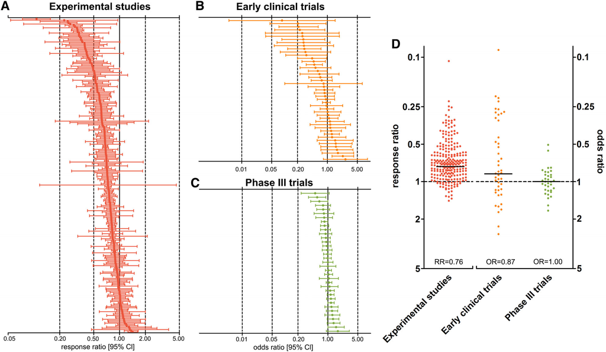

FIGURE 2: Treatment efﬁcacy. (A–C) Comparisons are ranked according to the effect on infarct volumes in experimental studies

and according to the effect on functional outcomes in early clinical trials and phase 3 clinical trials. Horizontal error bars indicate

95% conﬁdence interval (CI). (D) Scatter plots show the treatment effect of acute stroke studies for individual studies, and black

lines indicate the overall treatment effect. The overall treatment effect was 0.76 (95% CI = 0.70–0.83) in experimental studies,

0.87 (95% CI = 0.71–1.06) in early clinical, and 1.00 (95% CI = 0.95–1.06) in phase 3 clinical trials. Note that response ratios are

used to compare treatment effects on infarct volumes in experimental studies, whereas odds ratios are used to compare

treatment effects on functional outcomes in clinical trials.

44

Volume 87, No. 1

ANNALS of Neurology

treatments reduced stroke severity by 24% on average. For

functional outcomes, the overall response ratio of acute

stroke treatments in experimental studies was 0.78 (95%

CI = 0.67–0.91; Supplementary Fig 2).

In early clinical trials, the overall odds ratio was 0.87

(95% CI = 0.71–1.06; see Fig 2B), meaning that acute

stroke treatments improved outcome by 13% on average.

In phase 3 clinical trials, the overall odds ratio was 1.00

(95% CI = 0.95–1.06; see Fig 2C).

Altogether, our ﬁndings demonstrate a stepwise efﬁ-

cacy decline of acute stroke treatments from experimental

to early clinical trials to phase 3 clinical trials (see Fig 2D).

We next aimed to identify contributing factors explaining

this observed stepwise efﬁcacy decline. We used infarct

volume reduction in experimental studies and reduction

of neurological deﬁcits in clinical trials to determine treat-

ment efﬁcacy because the majority of experimental studies

provided infarct volumes as main outcomes, whereas most

clinical studies reported only neurological outcomes.

Publication Bias

The presence of publication bias is likely to contribute to

an overestimation of treatment efﬁcacy in meta-analyses

and systematic reviews.<sup>8</sup>Publication bias describes the phe-

nomenon that positive results are more likely to be publi-

shed, whereas negative data may either remain unpublished

or be presented in such a way that they become positive.<sup>9</sup>

We analyzed the prevalence of publication bias by funnel

plot asymmetry and a trim-and-ﬁll approach.<sup>8</sup>In brief, the

concepts of funnel plotting and trim and ﬁll are based on

the assumption that imprecise studies are as likely to over-

state efﬁcacy as to understate efﬁcacy. If publication bias is

present, there is an imbalance in favor of imprecise studies

that overstate efﬁcacy, whereas the counterpart of imprecise

studies that understate efﬁcacy is missing. Graphically, pub-

lication bias results in funnel plot asymmetry.<sup>8</sup>

Visual inspection of funnel plots showed that only

the plot of phase 3 clinical trials had an inverted funnel

shape (Fig 3A–C), indicating an absence of publication

bias in phase 3 clinical trials. In experimental studies,

there was a clear imbalance, with abundant imprecise

studies with large effect sizes, suggesting a high prevalence

of publication bias. In early clinical trials, there was a

moderate imbalance, with a modest number of imprecise

studies with large effect sizes, thus indicating a moderate

prevalence

of

publication

bias.

In

the

trim-and-ﬁll

approach, we imputed missing counterparts of imprecise

studies to get an idea of the number of unpublished exper-

iments (see Fig 3D–F). Trim-and-ﬁll method suggested

30 missing experimental studies, 11 missing early clinical

trials, and 1 missing phase 3 clinical trial. In addition, we

recalculated the overall efﬁcacy of the new data set to get

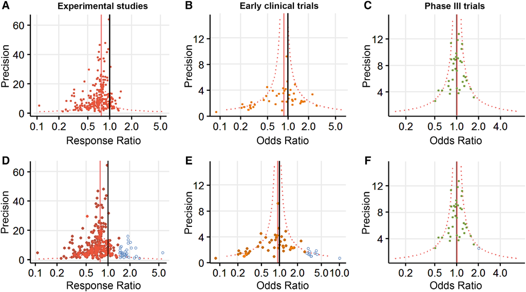

FIGURE 3: Publication bias. (A–C) Funnel plots with precision, that is, the reciprocal value of the standard error, plotted against

the effect size. In the absence of publication bias, the plots should resemble an inverted funnel. Visual inspection of funnel plot

asymmetry indicates the presence of publication bias in experimental studies and early clinical trials. (D–F) In the trim-and-ﬁll

January 2020

45

Schmidt-Pogoda et al: Why Neuroprotection Works in Animals

an estimate of the actual efﬁcacy in the absence of publica-

tion bias. The recalculated overall response ratio in experi-

mental studies was 0.78 (95% CI = 0.70–0.87), the

recalculated overall odds ratio in early clinical trials was

0.93 (95% CI = 0.7–1.19), and the recalculated overall

odds ratio in phase 3 clinical trials was 1.01 (95%

CI = 0.95–1.07). To verify our estimation of publication

bias, we additionally determined publication bias in clini-

cal trials by comparing trials that are registered with publi-

cations within 3 years following completion, similar to a

previously reported method.<sup>13</sup>Following this approach,

we identiﬁed 12 missing early clinical trials and no miss-

ing phase 3 trials. These results are in accordance with our

estimation of publication bias by funnel plot asymmetry

and trim and ﬁll, which suggested 11 missing early clinical

trials and 1 missing phase 3 trial.

Altogether, our ﬁndings identify publication bias as

an important contributing factor that leads to overstated

efﬁcacy of stroke treatments in experimental studies and

early clinical trials.

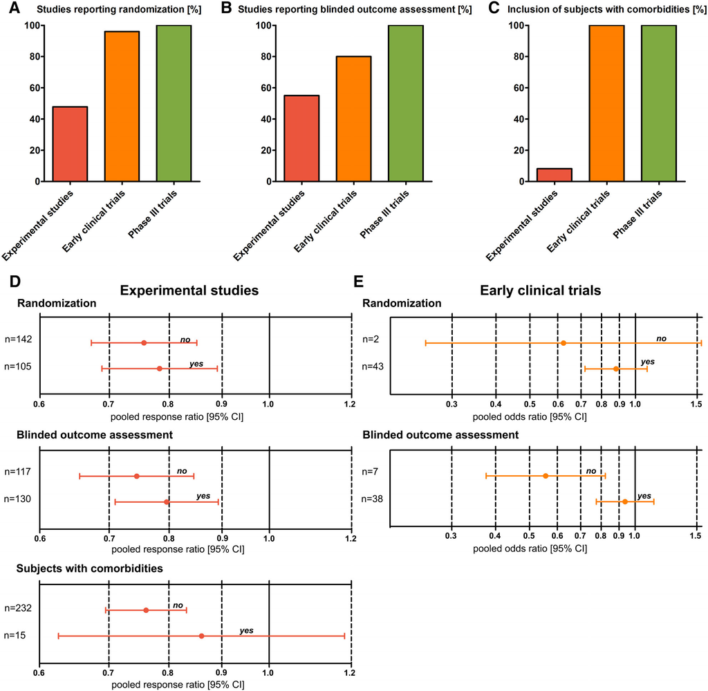

FIGURE 4: Impact of study quality on treatment efﬁcacy. (A–C) Bar graphs showing remarkable differences in the adherence to

quality criteria between experimental studies, early clinical trials, and phase 3 trials. (D, E) Meta-analyses illustrating the impact

of randomization, blinded outcome assessment, and inclusion of subjects with comorbidities on treatment efﬁcacy. Most

interestingly, acute stroke therapies did not show a signiﬁcant treatment effect in animals with comorbidities. Another important

observation is that unblinded early clinical trials demonstrated efﬁcacy of acute stroke treatments, whereas blinded studies did

not show signiﬁcant treatment effects. CI = conﬁdence interval.

46

Volume 87, No. 1

ANNALS of Neurology

Impact of Study Quality on Treatment Efﬁcacy

Low methodological quality of experimental studies is com-

monly regarded as a major culprit for the translational fail-

ure of animal research.<sup>14,15</sup>We systematically reviewed the

adherence to quality criteria and conducted meta-analyses

to assess the impact of randomization, blinding, and the

use of animals with comorbidities on the estimated efﬁcacy

of acute stroke treatments in experimental studies and clini-

cal trials. Only about half of the experimental studies

reported randomization and blinded outcome assessment,

whereas a vast majority of early clinical trials and all phase

3 trials obeyed these quality criteria (Fig 4). Also, only

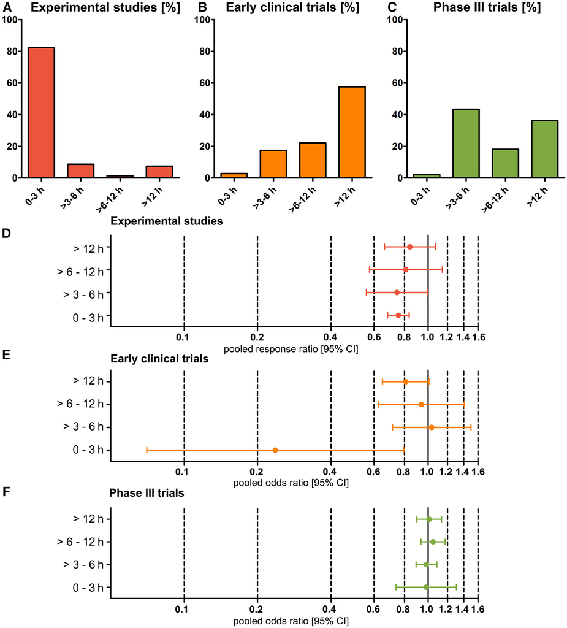

FIGURE 5: Impact of time to treatment on efﬁcacy. (A–C) Bar graphs illustrating considerable differences in the mean maximum

time to treatment between experimental studies and clinical trials. (D–F) Meta-analyses illustrating the impact of time to

treatment on treatment efﬁcacy. Our ﬁndings demonstrate that the efﬁcacy of acute stroke treatments is highly time

dependent. CI = conﬁdence interval.

January 2020

47

Schmidt-Pogoda et al: Why Neuroprotection Works in Animals

8.2% of experimental studies included subjects with com-

orbidities, whereas all early and phase 3 clinical trials

included patients with comorbidities. Notably, acute stroke

therapies did not have a signiﬁcant treatment effect in ani-

mals with comorbidities (response ratio = 0.86, 95%

CI = 0.63–1.18) versus animals without comorbidities

(response ratio = 0.76, 95% CI = 0.69–0.83). Another

important ﬁnding of our meta-analyses is that unblinded

early clinical trials demonstrate efﬁcacy of acute stroke

treatments, whereas blinded studies do not show signiﬁcant

treatment effects (odds ratio = 0.56, 95% CI = 0.38–0.82;

vs odds ratio = 0.94, 95% CI = 0.77–1.13).

In summary, these data show that neglecting quality

criteria contributes to an overestimation of treatment

efﬁcacy in experimental studies and early clinical trials.

Impact of Time to Treatment on Efﬁcacy

Treatment delays have a major impact on the efﬁcacy of acute

stroke treatments. We analyzed time to treatment in the

different study stages and assessed the inﬂuence of time to

treatment on observed treatment efﬁcacy. Of note, we found

a remarkable difference in time to treatment between experi-

mental studies and clinical trials. In the majority (82.38%) of

experimental studies, ﬁrst drug administration occurred

within the ﬁrst 3 hours after ischemia onset, whereas in most

clinical trials treatment was initiated later (Fig 5A–C).

Meta-analyses suggested that acute stroke treatments

in experimental studies achieved the greatest treatment

effects when initiated within the ﬁrst 3 hours after ische-

mia onset (see Fig 5D). With a treatment delay of

>6 hours, which is mostly seen in clinical trials, acute

stroke treatments did not yield overall signiﬁcant positive

results in experimental studies.

Similarly, acute stroke treatments achieved positive

effects in early clinical trials with a time to treatment of

up to 3 hours after ischemia onset, whereas studies with

later treatment initiation did not achieve overall signiﬁcant

positive results (see Fig 5E).

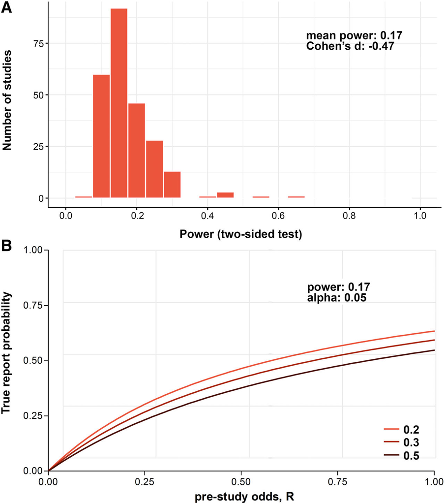

FIGURE 6: Power and true report probability. (A) The mean power in experimental studies was 17%. (B) True report probability

depends on power, prestudy odds of true H0 to H1 hypotheses, and bias. Because bias and prestudy odds cannot be assessed

precisely, we assumed different levels of bias and estimated the true report probability as a function of the prestudy odds. Even

under conservative assumptions, with a low bias of 0.3 and prestudy odds between 0.5 and 0.7, the estimated true report

probability of experimental stroke studies was lower than 50%.

48

Volume 87, No. 1

ANNALS of Neurology

Altogether, these data demonstrate that the efﬁcacy

of acute stroke treatments is highly time dependent

(Supplementary Fig 3). Better developed collateral systems

in human stroke patients compared to rodents may

increase the ischemic tolerance and potentially extend the

time window for neuroprotective treatments in human

stroke patients.<sup>16,17</sup>However, delayed treatment initiation

in clinical trials still remains a major factor contributing to

the efﬁcacy decline of acute stroke treatments from experi-

mental studies to clinical trials.

Power and True Report Probability

The reliability of a research ﬁnding may be deﬁned by its

true report probability, that is, the number of statistically

signiﬁcant true positive ﬁndings divided by the total num-

ber of reported statistically positive ﬁndings.<sup>12,18</sup>True

report probability depends on power, prestudy odds of

true H0 to H1 hypotheses, and bias, which in this context

refers to any manipulation that leads to the presentation

of intrinsically nonsigniﬁcant results as statistically signiﬁ-

cant.<sup>12,18</sup>For instance, a bias of 0.3 means that 30% of

ﬁndings that would be statistically nonsigniﬁcant in the

absence of bias will be reported as signiﬁcant.<sup>18</sup>

To estimate the true report probability of experimen-

tal stroke studies, we performed power calculations and

estimated a mean power of 17% (Fig 6). Because bias and

prestudy odds cannot be assessed precisely, we assumed dif-

ferent levels of bias and estimated the true report probabil-

ity as a function of prestudy odds. Even under the

optimistic assumption of a low bias of 0.3 and prestudy

odds between 0.5 and 0.7, the estimated true report proba-

bility of experimental stroke studies was lower than 50%.

These ﬁndings indicate that even under conservative

estimates, less than half of the published positive experi-

mental stroke studies are truly positive.

Discussion

Our study shows a stepwise efﬁcacy decline of acute stroke

treatments from experimental studies to early clinical trials

to phase 3 clinical trials. This stepwise efﬁcacy decline is

explained by publication bias, noncompliance with quality

criteria, differences in study design (eg, treatment time win-

dow), and low power of experimental studies and early clini-

cal trials.

We found a clear publication bias in experimental

studies and early clinical trials, with a number of

unpublished studies. Nonpublication of negative data

obviously contributes to overestimated efﬁcacy of experi-

mental studies and early clinical trials. In addition, non-

publication of animal experiments raises major ethical

concerns. First, animals have been sacriﬁced without

advancing the knowledge of medical research. Second,

patients partaking in clinical trials are deceived by over-

estimated treatment efﬁcacy in preceding animal studies.<sup>8</sup>

To avoid publication bias in future studies, the implemen-

tation of a database has been suggested, registering all

planned animal stroke studies in advance and ensuring

studies are published even if study results are neutral or

negative.<sup>19</sup>If primary end points and statistical methods

were deﬁned a priori, this would also prevent selective

outcome reporting and selective analysis reporting.

Another important ﬁnding is that noncompliance

with quality criteria contributed to an overestimation of

treatment efﬁcacy in experimental studies and early clini-

cal trials. Randomization and blinding have been proposed

as means to maximize the internal validity of animal

experiments,

meaning

that

the

difference

observed

between animals of different treatment arms is in fact

attributable to the intervention under investigation.<sup>20</sup>

Randomization prevents the experimenter from allocating

animals thought to perform either particularly well or

badly to a certain treatment arm.<sup>20</sup>Blinding inhibits a sys-

tematic distortion of study results, which may occur when

the investigator who assesses outcomes knows the treat-

ment allocation. Moreover, blinding excludes differences

in care between the treatment groups.<sup>20</sup>

The use of animals with comorbidities has been pro-

posed as a means to increase the external validity of exper-

imental stroke studies.<sup>20</sup>In this context, high external

validity means that animal models mirror the clinical situ-

ation, where most stroke patients are old and morbid.

Animal studies performed in young and healthy animals,

as is the case in most experimental stroke studies, have

low external validity. Our meta-analysis highlights that

acute stroke treatments had no overall signiﬁcant treat-

ment effects in animals with comorbidities, whereas there

was a large treatment effect in young and healthy animals.

These ﬁndings demonstrate that poor external validity

contributed considerably to overestimated efﬁcacy of

stroke treatments in experimental studies.

Our systematic analysis highlights intriguing differ-

ences in the study designs of experimental studies and

clinical trials. For instance, almost all experimental studies

provided infarct volumes as main end points, whereas

most clinical studies reported neurological outcomes only.

In addition, the treatment initiation was substantially del-

ayed in clinical trials compared to experimental studies.

Because early initiated treatment achieved best effects in

experimental studies, it is likely that the treatment delay

observed in clinical trials reduced the efﬁcacy of acute

stroke treatments, thus adding to the observed efﬁcacy

decline from experimental studies to clinical trials. To pre-

vent translational failures due to study design differences

between experimental studies and clinical trials, we suggest

January 2020

49

Schmidt-Pogoda et al: Why Neuroprotection Works in Animals

conceptualizing future experimental studies in a study

design that is 1:1 transferable into clinical trials.

Power has a major impact on the reliability of

research ﬁndings.<sup>21</sup>According to our power estimation,

the mean power of experimental studies was 17%. Tech-

nically, low power means that a study can only detect

large treatment effects.<sup>21</sup>However, low-powered studies

that coincidentally overestimate the dimension of a treat-

ment effect can also detect treatment effects that are in

truth small.<sup>21</sup>By inﬂation of effect sizes, low-powered

experimental studies may thus have contributed to an

overestimated efﬁcacy of acute stroke treatments. In addi-

tion, low power is a main culprit for poor true report

probability in experimental studies. As detailed previously,

true report probability depends on power, prestudy odds

of true H0 to H1 data, and bias. The prestudy odds can-

not be inﬂuenced by the experimenter. Bias cannot be

completely excluded either, although major types of bias

like publication bias and reporting bias could be elimi-

nated by preregistering studies and a priori deﬁning pri-

mary end points. Power, by contrast, could be increased

easily by implementing a priori sample size calculations.

Our study has strengths and limitations. A limitation

of our study is that we cannot assess selective outcome

reporting and selective analysis reporting in experimental

studies. This leads to an underestimation of bias in experi-

mental studies. For early clinical trials and phase 3 clinical

trials, we systematically compared primary and secondary

end points listed in ClinicalTrials.gov to reported end

points in published studies and found no evidence for

selective reporting in registered early clinical trials and

phase 3 trials. Another limitation is that power estimations

were based on results that were inﬂuenced by publication

bias. This leads to an overestimation of power, with the

true power being even lower than our estimated value.

We addressed heterogeneity by comparing effects sizes

between different stroke models and stroke subtypes. Our

results

show

that

experimental

studies

and

early

phase clinical trials overestimate treatment effects of

neuroprotectants independent of stroke models in experi-

mental studies and stroke subtypes in clinical trials. These

ﬁndings strongly support the existence of an efﬁcacy

decline independent of differences in heterogeneity. None-

theless, we cannot rule out heterogeneity as a contributing

factor to the failure of trials at phase 3.

The comprehensive and systematic approach is a

strength of our study. We provide the ﬁrst systematic

review and meta-analysis of virtually all medical treatments

for acute ischemic stroke that have been under investiga-

tion in experimental studies, early clinical trials, and phase

3 clinical trials. Our large data set allows meaningful con-

clusions about translational difﬁculties in stroke research,

and some of our methodological conclusions can be trans-

ferred to other ﬁelds of medical research.

Conclusion

In addition to the well-characterized translational road-

block between preclinical and clinical studies, our study

unveils further obstacles on the path from early phase to

phase 3 clinical trials. Most importantly, we identiﬁed

major study design differences between experimental stud-

ies and clinical trials. For instance, most experimental

studies use rodent models of middle cerebral artery occlu-

sion with large hemispheric infarcts and examine infarct

volumes in the acute phase as primary outcomes, whereas

most clinical trials include various stroke etiologies and

determine neurological outcomes in the chronic phase as

primary outcomes. Delayed treatment initiation in clinical

trials is another major study design difference explaining

failed translation from experimental studies to clinical

trials.

Beyond

these

differences

in

study

design,

noncompliance with quality criteria and low power are

pivotal methodological weaknesses contributing to the

gradual efﬁcacy decline of acute stroke treatments from

experimental studies to early phase clinical trials and from

early phase clinical trials to phase 3 clinical trials. Surpris-

ingly, our estimations of power and true report probability

suggest that less than half of the published positive experi-

mental stroke studies are truly positive.

Acknowledgment

This study was supported by a research grant of the Inter-

disciplinary Center for Clinical Research of the Medical

Faculty of the University of Münster (SEED07, A.S.-P.),

by the Deutsche Forschungsgemeinschaft (MI 1547/3-1), by

the Else Kröner-Fresenius-Stiftung (J.M., 2014_EKES.16),

and by the DAAD grant 57403633.

Author Contributions

A.S.-P., N.B., H.M., and J.M. developed the study con-

cept and design; A.S.-P., N.B., M.H.M.K., J.W., N.-M.

B., and C.B. were involved in data acquisition and analy-

sis; and A.S.-P., J.-K.S., W.-R.S., S.G.M., H.W., and

J.M. drafted the manuscript and ﬁgures.

Potential Conﬂicts of Interest

Nothing to report.

References

1. Benjamin EJ, Blaha MJ, Chiuve SE, et al. Heart disease and stroke

statistics-2017 update: a report from the American Heart Association.

Circulation 2017;135:e146–e603.

50

Volume 87, No. 1

ANNALS of Neurology

2. Powers WJ, Rabinstein AA, Ackerson T, et al. 2018 guidelines for the

early management of patients with acute ischemic stroke: a guideline for

healthcare professionals from the American Heart Association/American

Stroke Association. Stroke 2018;49:e46–e110.

3. O’Collins VE, Macleod MR, Donnan GA, et al. 1,026 experimental

treatments in acute stroke. Ann Neurol 2006;59:467–477.

4. Hackam DG. Translating animal research into clinical beneﬁt. BMJ

2007;334:163–164.

5. Hackam DG, Redelmeier DA. Translation of research evidence from

animals to humans. JAMA 2006;296:1731–1732.

6. Hedges LV, Gurevitch J, Curtis PS. The meta-analysis of response

ratios in experimental ecology. Ecology 1999;80:1150–1156.

7. Viechtbauer W. Conducting meta-analyses in R with the metafor

package. J Stat Softw 2010;36:1–48.

8. Sena ES, van der Worp HB, Bath PM, et al. Publication bias in reports

of animal stroke studies leads to major overstatement of efﬁcacy.

PLoS Biol 2010;8:e1000344.

9. Sterne JA, Sutton AJ, Ioannidis JP, et al. Recommendations for

examining and interpreting funnel plot asymmetry in meta-analyses

of randomised controlled trials. BMJ 2011;343:d4002.

10. Duval S, Tweedie R. Trim and ﬁll: a simple funnel-plot-based method

of testing and adjusting for publication bias in meta-analysis. Biomet-

rics 2000;56:455–463.

11. Champely S. Pwr: basic functions for power analysis. R package ver-

sion 1.2-2. Available at: https://CRAN.R-project.org/package=pwr.

Last assessed May 2019.

12. Ioannidis JP. Why most published research ﬁndings are false. PLoS

Med 2005;2:e124.

13. J Gill A, A Barletta J. Annual review issue: endocrine pathology: a

pathological,

clinical

and molecular integration. Histopathology

2018;72:3.

14. Sena E, van der Worp HB, Howells D, Macleod M. How can we

improve the pre-clinical development of drugs for stroke? Trends

Neurosci 2007;30:433–439.

15. Macleod MR, Lawson McLean A, Kyriakopoulou A, et al. Risk of bias

in reports of in vivo research: a focus for improvement. PLoS Biol

2015;13:e1002273.

16. McColl BW, Carswell HV, McCulloch J, Horsburgh K. Extension of

cerebral hypoperfusion and ischaemic pathology beyond MCA terri-

tory after intraluminal ﬁlament occlusion in C57Bl/6J mice. Brain Res

2004;997:15–23.

17. Nogueira RG, Jadhav AP, Haussen DC, et al. Thrombectomy 6 to

24 hours after stroke with a mismatch between deﬁcit and infarct.

N Engl J Med 2018;378:11–21.

18. Szucs D, Ioannidis JP. Empirical assessment of published effect sizes

and power in the recent cognitive neuroscience and psychology lit-

erature. PLoS Biol 2017;15:e2000797.

19. Liebeskind DS, Kidwell CS, Sayre JW, Saver JL. Evidence of publica-

tion bias in reporting acute stroke clinical trials. Neurology 2006;67:

973–979.

20. van der Worp HB, Howells DW, Sena ES, et al. Can animal models

of disease reliably inform human studies? PLoS Med 2010;7:

e1000245.

21. Button KS, Ioannidis JP, Mokrysz C, et al. Power failure: why small

sample size undermines the reliability of neuroscience. Nat Rev

Neurosci 2013;14:365–376.

January 2020

51

Schmidt-Pogoda et al: Why Neuroprotection Works in Animals